# Demand Forecasting

2023-01-25

## 1. Introduction

Businesses use various marketing strategies to boost sales, including price-based promotions (e.g., discounts) and non-price promotions (e.g., lotteries). Advertising is another key element, commonly seen in billboards and increasingly through online campaigns on platforms like YouTube. Pricing also plays a crucial role, as competitive prices can drive purchases.

A core concern for businesses investing in marketing is measuring its impact-whether through consumer perceptions over time or direct contributions to sales.

This project examines shampoo sales from two brands, 1 and 2, addressing the following questions:

*1. How do the marketing mix elements (promotion, advertising, and price) and consumer perception influence shampoo sales for brands 1 and 2?*

*2. Which model-multivariate linear regression or a neural network-better predicts future shampoo sales?*

Answering these questions will provide insights into the effectiveness of different marketing strategies and guide investment decisions. The second question contributes to the understanding of predictive modeling, evaluating the strengths and limitations of each approach to inform future research.

## 2. Data

### Dataset

This report analyzes shampoo sales data from an anonymous company for two brands, 1 and 2. The data was collected through a nationally representative household survey and spans eight years (96 months).

For each brand, the dataset includes three marketing mix variables:  
*Promotion* - Percentage of products on promotion.  
*Advertising* - Advertising expenditure (in thousands of Euros).  
*Price* - Average price per unit weight.

Additionally, the dataset includes:  
*Sales* - Sales volume (in thousands).  
*Time* - Temporal integer representing the month.  
*Brand Awareness* - Percentage of households aware of the product (seen, heard, or read about it). *Consideration* - Percentage of households considering purchasing the product.  
*Liking* - Average product rating on a scale of 1 to 7.

This data provides insights into the relationship between marketing efforts, consumer perception, and sales performance over time.

```r
#set directory
setwd("F:/Markt Proj")
# load the datasets
shampoo <- read_excel("shampoo (with descriptions).xls")
print(names(shampoo))
```

```
##  [1] "category"      "brand"         "time"          "consideration"
##  [5] "liking"        "awareness"     "promotion"     "advertising"
##  [9] "price"         "sales"
```

Table 1 shows a sample of the data

```r
# display sample
kable(head(shampoo[,2:10]), caption = "Table 1 Original Dataset")%>%
  kable_styling(bootstrap_options = c("striped", "hover", "condensed"))
```

Table 1 Original Dataset

| brand | time | consideration | liking | awareness | promotion | advertising | price | sales |
| --- | --- | --- | --- | --- | --- | --- | --- | --- |
| 1 | 1 | 16.28 | 5.006 | 22.12 | 16.28 | 478.690 | 1.552467 | 1691.97 |
| 1 | 2 | 19.28 | 4.848 | 27.46 | 22.16 | 686.173 | 1.788294 | 2002.41 |
| 1 | 3 | 18.21 | 4.849 | 22.58 | 48.55 | 0.000 | 2.450071 | 2621.36 |
| 1 | 4 | 19.62 | 4.892 | 25.61 | 28.54 | 521.985 | 2.027777 | 1800.00 |
| 1 | 5 | 18.61 | 4.854 | 28.96 | 19.99 | 568.787 | 1.903465 | 1882.72 |
| 1 | 6 | 20.07 | 4.864 | 27.72 | 32.48 | 0.000 | 2.042402 | 2265.12 |

```r
rows <- c(172:182,1:10)

# display sample
kable(head(shampoo[rows,2:10]),caption = "Sample Data")%>%
  kable_styling(bootstrap_options = c("striped", "hover", "condensed"))
```

Sample Data

| brand | time | consideration | liking | awareness | promotion | advertising | price | sales |
| --- | --- | --- | --- | --- | --- | --- | --- | --- |
| 2 | 76 | 32.35 | 6.1660 | 25.74 | 79.42 | 0 | 4.325716 | 4952.29 |
| 2 | 77 | 27.40 | 6.0278 | 27.85 | 54.31 | 1184 | 4.307435 | 3870.87 |
| 2 | 78 | 33.75 | 6.3311 | 26.01 | 59.49 | 918 | 4.051499 | 3373.87 |
| 2 | 79 | 32.89 | 6.2906 | 26.96 | 47.19 | 1290 | 4.325716 | 3697.63 |
| 2 | 80 | 31.79 | 6.1086 | 27.05 | 65.17 | 389 | 4.380559 | 6181.88 |
| 2 | 81 | 29.32 | 5.9386 | 23.69 | 51.80 | 1315 | 4.179467 | 4793.60 |

### Descriptive Analysis

```r
# Summary statistics for each brand
shampoo %>%
  group_by(brand) %>%
  summarise(
    Mean_Sales = mean(sales, na.rm = TRUE),
    Median_Sales = median(sales, na.rm = TRUE),
    Mean_Price = mean(price, na.rm = TRUE),
    Median_Price = median(price, na.rm = TRUE),
    Count = n()
  )
```

| brand | Mean_Sales | Median_Sales | Mean_Price | Median_Price | Count |
| --- | --- | --- | --- | --- | --- |
| 1 | 2357.507 | 2301.855 | 2.063615 | 2.061597 | 96 |
| 2 | 4243.326 | 4168.530 | 3.936385 | 3.987515 | 96 |

```r
# Summary statistics for each brand
shampoo %>%
  group_by(brand) %>%
  summarise(
    Mean_consideration = mean(consideration, na.rm = TRUE),
    Mean_liking = mean(liking, na.rm = TRUE),
    Mean_awareness = mean(awareness, na.rm = TRUE),
    Median_promotion = median(promotion, na.rm = TRUE),
    Mean_advertising = mean(advertising, na.rm = TRUE)
  )
```

| brand | Mean_consideration | Mean_liking | Mean_awareness | Median_promotion | Mean_advertising |
| --- | --- | --- | --- | --- | --- |
| 1 | 17.07271 | 4.932629 | 21.51562 | 24.665 | 355.5734 |
| 2 | 30.99625 | 6.161833 | 27.43562 | 46.570 | 1073.0306 |

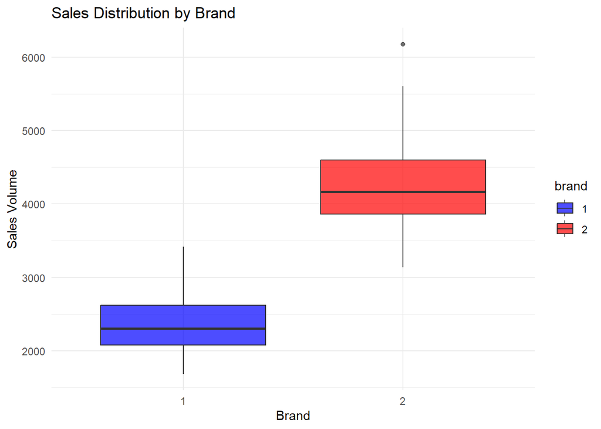

```r
# Convert brand to a factor
shampoo$brand <- as.factor(shampoo$brand)

# Boxplot of Sales by Brand
ggplot(shampoo, aes(x = brand, y = sales, fill = brand)) +
  geom_boxplot(alpha = 0.7) +
  labs(title = "Sales Distribution by Brand", x = "Brand", y = "Sales Volume") +
  scale_fill_manual(values = c("blue", "red")) +
  theme_minimal()
```

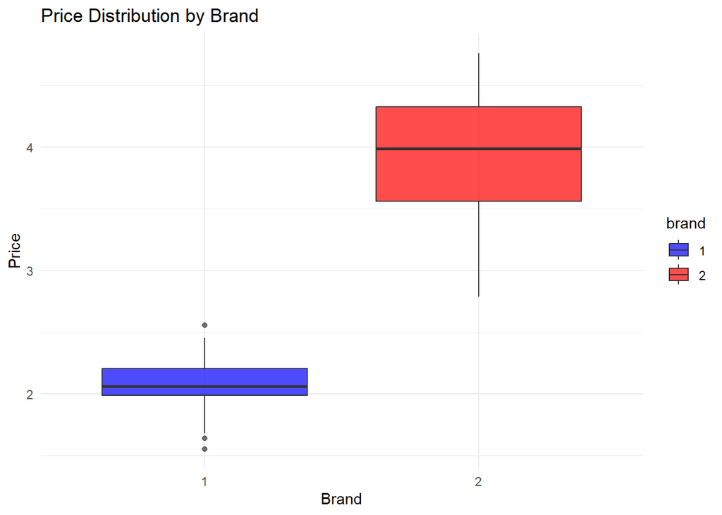

```r
# Convert brand to a factor
shampoo$brand <- as.factor(shampoo$brand)

# Boxplot of Sales by Brand
ggplot(shampoo, aes(x = brand, y = price, fill = brand)) +
  geom_boxplot(alpha = 0.7) +
  labs(title = "Price Distribution by Brand", x = "Brand", y = "Price") +
  scale_fill_manual(values = c("blue", "red")) +
  theme_minimal()
```

Figures 1-3 show that Brand 2 allocates more spending to advertising and spends more time on promotions compared to Brand 1. Additionally, the price paid per unit weight is relatively higher for Brand 2.

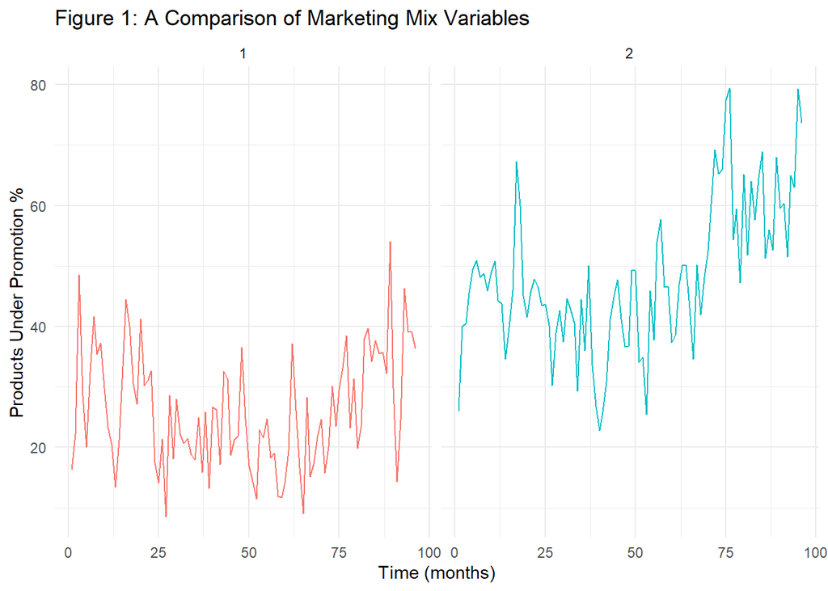

```r
library(gridExtra)

# Plot promotion for each brand separately
ggplot(shampoo, aes(x = time, y = promotion,  color = brand)) +
  geom_line() +
  labs(title = "Figure 1: A Comparison of Marketing Mix Variables",
       x = "Time (months)",
       y = "Products Under Promotion %") +
  facet_grid(~brand) +
  theme_minimal()+
  theme(legend.position = "none")
```

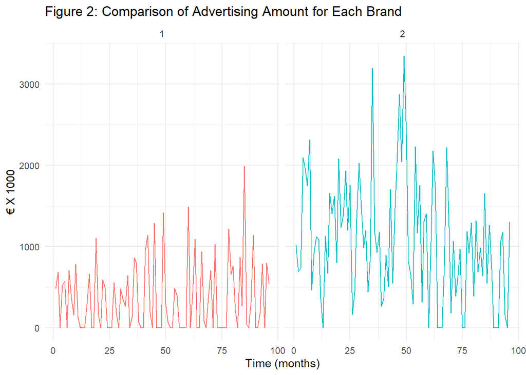

```r
# Plot advertisement for each brand separately
ggplot(shampoo, aes(x = time, y = advertising,  color = brand)) +
  geom_line() +
  labs(title = "Figure 2: Comparison of Advertising Amount for Each Brand",
       x = "Time (months)",
       y = "€ X 1000") +
  facet_grid(~brand) +
  theme_minimal()+
  theme(legend.position = "none")
```

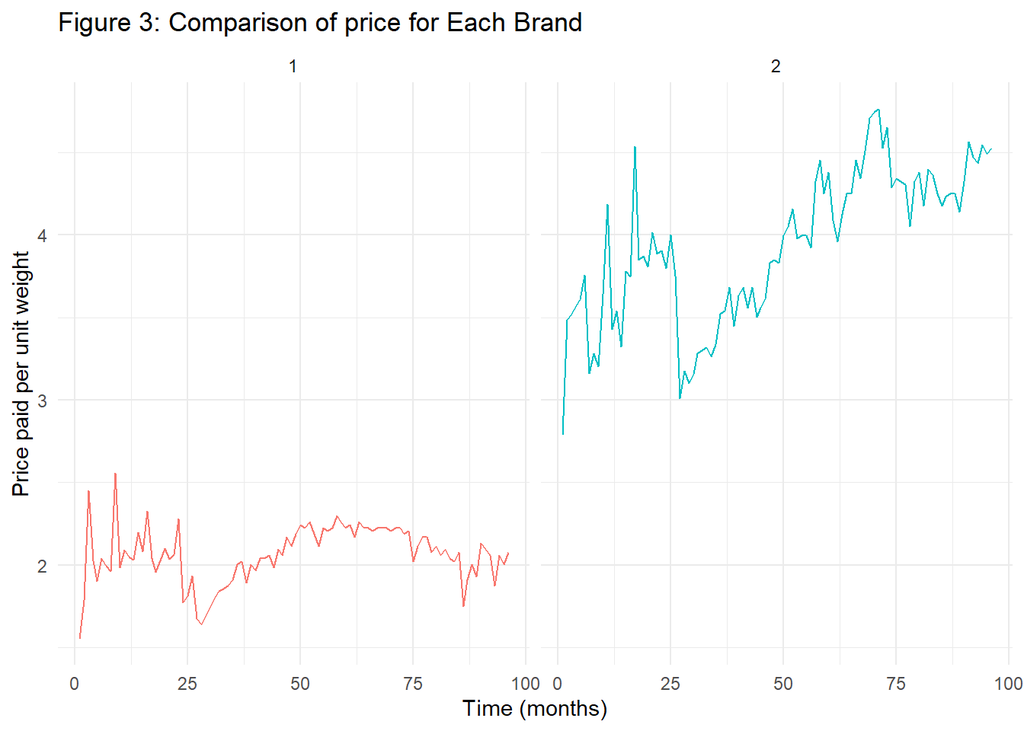

```r
# Plot Price for each brand separately
ggplot(shampoo, aes(x = time, y = price,  color = brand)) +
  geom_line() +
  labs(title = "Figure 3: Comparison of price for Each Brand",
       x = "Time (months)",
       y = "Price paid per unit weight") +
  facet_grid(~brand) +
  theme_minimal()+
  theme(legend.position = "none")
```

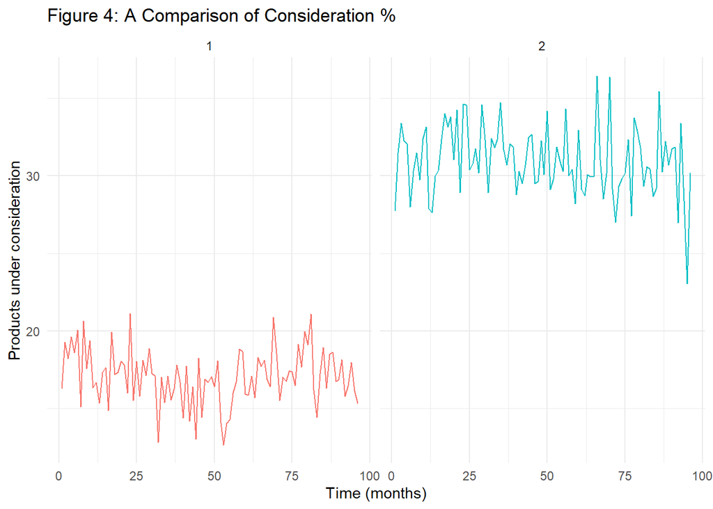

```r
# Plot consideration for each brand separately
ggplot(shampoo, aes(x = time, y = consideration,  color = brand)) +
  geom_line() +
  labs(title = "Figure 4: A Comparison of Consideration %",
       x = "Time (months)",
       y = "Products under consideration") +
  facet_grid(~brand) +
  theme_minimal()+
  theme(legend.position = "none")
```

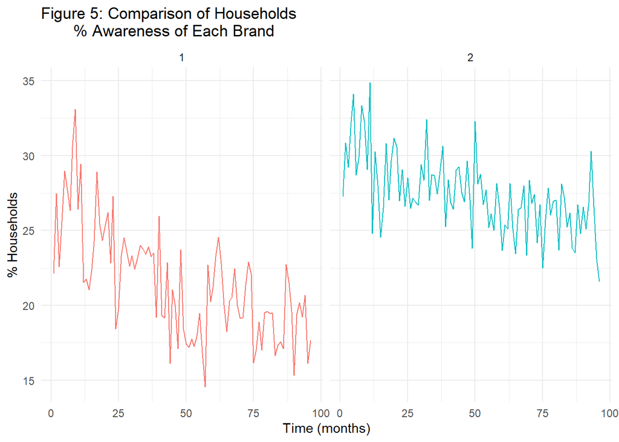

```r
# Plot awareness for each brand separately
ggplot(shampoo, aes(x = time, y = awareness,  color = brand)) +
  geom_line() +
  labs(title = "Figure 5: Comparison of Households
       % Awareness of Each Brand",
       x = "Time (months)",
       y = "% Households") +
  facet_grid(~brand) +
  theme_minimal()+
  theme(legend.position = "none")
```

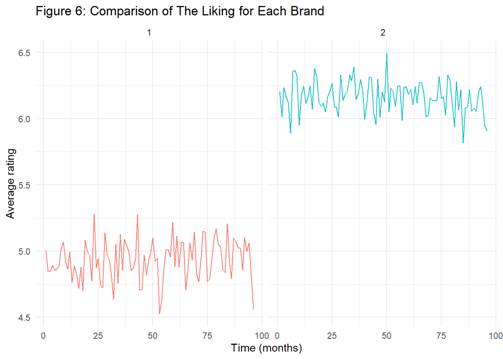

```r
# Plot liking for each brand separately
ggplot(shampoo, aes(x = time, y = liking,  color = brand)) +
  geom_line() +
  labs(title = "Figure 6: Comparison of The Liking for Each Brand",
       x = "Time (months)",
       y = "Average rating") +
  facet_grid(~brand) +
  theme_minimal()+
  theme(legend.position = "none")
```

Figure 7 indicates that sales are relatively price-sensitive, as both brands experience corresponding shifts in sales with changes in price.

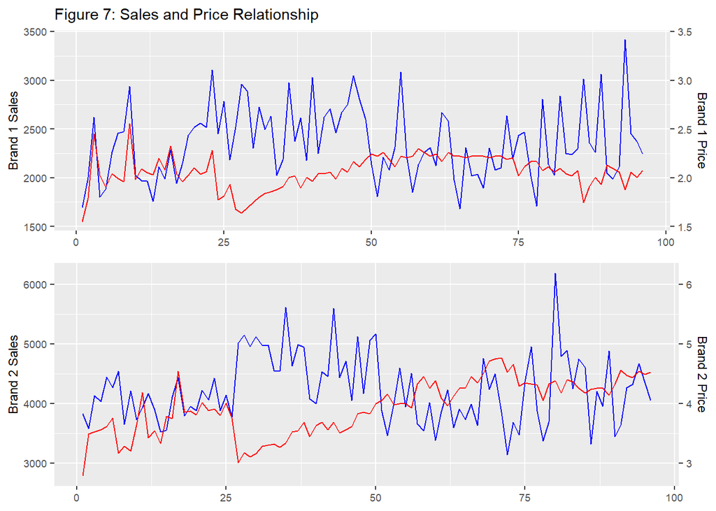

```r
#split the data for brand 1 & 2
shampoo1 <- shampoo %>% filter(brand == 1)
shampoo2 <- shampoo %>% filter(brand == 2)

b1 <- shampoo1 %>% ggplot() + geom_line(aes(x=time, y=sales), colour="blue") + geom_line(aes(x = time, y = price*1000), colour="red") + scale_y_continuous(sec.axis = sec_axis(~. / 1000 , name="Brand 1 Price")) + labs(y="Brand 1 Sales", title = "Figure 7: Sales and Price Relationship", x = NULL) +
theme(text = element_text(size=9))

b2 <- shampoo2 %>% ggplot() + geom_line(aes(x=time, y=sales), colour="blue") + geom_line(aes(x = time, y = price*1000), colour="red") + scale_y_continuous(sec.axis = sec_axis(~. / 1000 , name="Brand 2 Price")) + labs(y="Brand 2 Sales", x=NULL) +
theme(text = element_text(size=9))


grid.arrange(b1,b2,nrow=2)
```

## 3. Impact of Marketing Mix Variables on Sales and Consumer Perceptions

This section aims to answer the question:

*How do the marketing mix elements (promotion, advertising, and price) and consumer perception influence shampoo sales for brands 1 and 2?*

### Traditional MLR model

The multivariate linear regression (MLR) model is an extension of simple linear regression that allows for predicting dependent variables based on multiple independent variables (Alexopoulos, 2010). In MLR, the relationship between the dependent variable $Y$ and multiple independent variables $X_{1}$, $X_{2}$…$X_{n}$is modeled using a linear equation with the general form:
$$Y=β_{0}+β_{1}X_{1}+β_{2}X_{2}+...β_{n}X_{n}+ϵ$$
Where, $β_{0}$ is the intercept, $β_{1}$, $β_{2}$, $β_{n}$ are coefficients or slope parameters, and $ϵ$ is the error. In this case, the sales of a shampoo brand, $s$ at month $m$ can be estimated as a function of the brand’s Price and its competitor, the promotion, and advertising as below:
$$Sales_{sm} = \sum_{b=1}^2 \beta_{sc}Price_{cm} + \sum_{b=1}^2 \gamma_{sc}Advertising_{cm} + \sum_{b=1}^2 \omega_{sc}Promotion_{cm} +\epsilon_{sm}$$

### Adjusted MLR

Certain products experience seasonal demand fluctuations, such as dairy products, which see higher sales during holidays. However, since the exact dates in this dataset are unknown, this project introduces dummy variables for months to analyze seasonality. Additionally, monthly data is incorporated into the adjusted MLR model to examine its impact on sales.

Beyond traditional MLR variables, three consumer perception metrics-liking, consideration, and awareness-are included, as higher values in these areas typically indicate stronger sales potential. Adjustments were made to the model to account for these factors.

As shown in Figure 8, sales exhibit seasonal trends, with peak influence observed mid-year, typically during summer. To capture this effect, a dummy variable for summer months (June-September) was added. However, the results also indicate that multiple other factors contribute to sales variations.

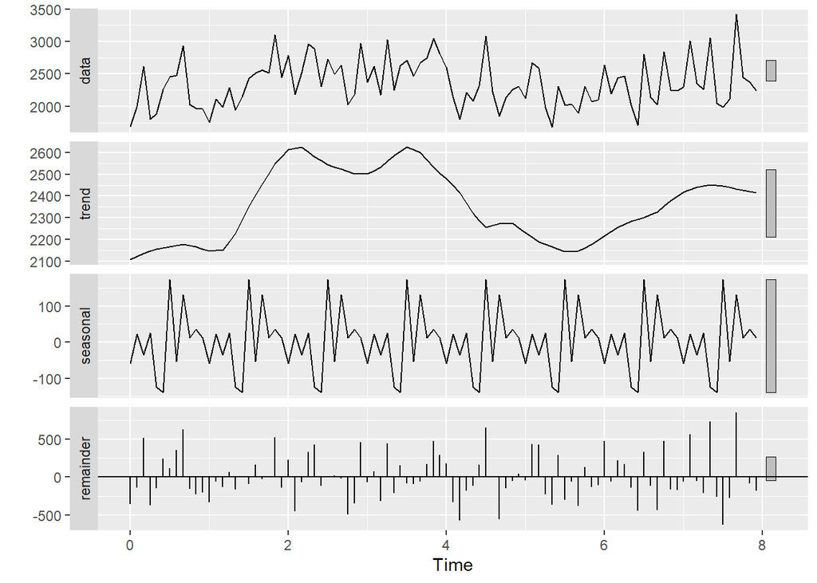

```r
#split & join data
shampoo1 <- shampoo %>% filter(brand == 1)
shampoo2 <- shampoo %>% filter(brand == 2)
shampoo1$consideration_2 <- shampoo2$consideration
shampoo1$liking_2 <- shampoo2$liking
shampoo1$awareness_2 <- shampoo2$awareness
shampoo1$promotion_2 <- shampoo2$promotion
shampoo1$advertising_2 <- shampoo2$advertising
shampoo1$price_2 <- shampoo2$price
shampoo1$sales_2 <- shampoo2$sales
ts_shampoo1 <- ts(shampoo1, frequency = 12, start=c(0,1))
plot_sales <- ts_shampoo1[,10]
plot_sales %>% stl(s.window = "period") %>% autoplot(caption = "Figure 8: Time Series Decomposition for Sales for brand 1")
```

```r
# Create monthly dummies
shampoo1 <- shampoo1 %>% mutate(
  jan = ifelse(time %in% c(1, 13, 25, 37, 49, 61, 73, 85), 1, 0),
  feb = ifelse(time %in% c(2, 14, 26, 38, 50, 62, 74, 86), 1, 0),
  mar = ifelse(time %in% c(3, 15, 27, 39, 51, 63, 75, 87), 1, 0),
  apr = ifelse(time %in% c(4, 16, 28, 40, 52, 64, 76, 88), 1, 0),
  may = ifelse(time %in% c(5, 17, 29, 41, 53, 65, 77, 89), 1, 0),
  june = ifelse(time %in% c(6, 18, 30, 42, 54, 66, 78, 90), 1, 0),
  july = ifelse(time %in% c(7, 19, 31, 43, 55, 67, 79, 91), 1, 0),
  aug = ifelse(time %in% c(8, 20, 32, 44, 56, 68, 80, 92), 1, 0),
  sept = ifelse(time %in% c(9, 21, 33, 45, 57, 69, 81, 93), 1, 0),
  oct = ifelse(time %in% c(10, 22, 34, 46, 58, 70, 82, 94), 1, 0),
  nov = ifelse(time %in% c(11, 23, 35, 47, 59, 71, 83, 95), 1, 0),
  dec = ifelse(time %in% c(12, 24, 36, 48, 60, 72, 84, 96), 1, 0)
)
#Summer season dummies(June to Septmeber)
shampoo1 <- shampoo1 %>% mutate(summer = ifelse(time %in% c(6, 18, 30, 42, 54, 66, 78, 90,7, 19, 31, 43, 55, 67, 79, 91, 8, 20, 32, 44, 56, 68, 80, 92, 9, 21, 33, 45, 57, 69, 81, 93), 1, 0))
```

When adjusted the equation to be used is:
$$S_{sm} = \sum_{b=1}^2 \beta_{sc}P_{cm} + \sum_{b=1}^2 \gamma_{sc}Ad_{cm} + \sum_{b=1}^2 \omega_{sc}Pr_{cm} + \sum_{b=1}^2 \rho_{sk}Aw_{cm} +\sum_{b=1}^2 \theta_{sk}Li_{cm} +\sum_{b=1}^2 \alpha_{sk}C_{cm} + \sum_{b=1}^{12} M_{d}\mu_{sm}+ Su\phi_{sc} +\epsilon_{sm}$$
Where:

$S_{sm}$ = Sales volume for brand

$c$ in month $m$ $P_{cm}$ = Price of brand $c$ in month $m$

$Ad_{cm}$ = amount spent on Advertising brand $c$ in month $m$

$Pr_{cm}$ = % of brand $c$ being promoted in month $m$

$Aw_{sm}$ = % of awareness of brand $c$ in month $m$

$Co_{sm}$ = % of consideration of brand $c$ in month $m$

$Li_{sm}$ = Average likeness rating of brand $c$ in month $m$

$M_{d}$ = 1 if the month is month $d$

$Su$ = 1 if the month $s$ is summer

The data must undergo log transformation to normalize its distribution, particularly when it is highly skewed or spans a wide range of values. This transformation enhances the performance of statistical models that assume normality, such as the MLR model. Thus:

$$\log(S_{sm}) = \sum_{b=1}^2 \beta_{sc}\log(P_{cm}) + \sum_{b=1}^2 \gamma_{sc}\log(Ad_{cm}) + \sum_{b=1}^2 \omega_{sc}\log(Pr_{cm}) + \sum_{b=1}^2 \rho_{sk}\log(Aw_{cm}) +\sum_{b=1}^2 \theta_{sk}\log(Li_{cm}) +\sum_{b=1}^2 \alpha_{sk}\log(C_{cm}) + \sum_{b=1}^{12} M_{d}\log(\mu_{sm})+ Su\log(\phi_{sc}) +\epsilon_{sm}$$

### Application

70% of the data was used for training, while 30% was used for model testing.

```r
library(car)
#Log transformation
shampoo1$Logsales <- log(shampoo1$sales)
shampoo1$Logsales_2 <- log(shampoo1$sales_2)

shampoo1$Logprice <- log(shampoo1$price)
shampoo1$Logprice_2 <- log(shampoo1$price_2)

shampoo1$Logliking <- log(shampoo1$liking)
shampoo1$Logliking_2 <- log(shampoo1$liking_2)

shampoo1$Logawareness <- log(shampoo1$awareness)
shampoo1$Logawareness_2 <- log(shampoo1$awareness_2)

shampoo1$Logconsideration <- log(shampoo1$consideration)
shampoo1$Logconsideration_2 <- log(shampoo1$consideration_2)

shampoo1$Logpromotion <- log(shampoo1$promotion)
shampoo1$Logpromotion_2 <- log(shampoo1$promotion_2)

shampoo1$Logadvertising <- log(shampoo1$advertising)
shampoo1$Logadvertising_2 <- log(shampoo1$advertising_2)

#split training & testing data for model
train_shampoo1 <- round(nrow(shampoo1)*0.70,0)
shampoo1_train <- shampoo1[1:train_shampoo1,]
shampoo1_test <- shampoo1[(train_shampoo1+1):96,]

#use model

mlr_1 <- lm(Logsales ~ Logprice + Logprice_2 + promotion + promotion_2 + advertising + advertising_2 + liking + awareness + consideration + liking_2 + awareness_2 + consideration_2 + summer, data=shampoo1_train)

mlr_2 <- lm(Logsales_2 ~ Logprice + Logprice_2 + promotion + promotion_2 + advertising + advertising_2 + liking + awareness + consideration + liking_2 + awareness_2 + consideration_2 + summer, data=shampoo1_train)


# Calculate the correlation matrix
corr_matrix <- cor(shampoo1[, c("price", "price_2" , "promotion" , "promotion_2" , "advertising" , "advertising_2" , "liking" , "awareness" , "consideration" , "consideration_2" , "summer")])
#correlation matrix in appendix

stargazer(mlr_1, mlr_2, header = FALSE, title="Table 2: Adjusted MLR Model Regression Results", type = "html")
```

**Table 2: Adjusted MLR Model Regression Results**

|  | *Dependent variable:* |  |
| --- | --- | --- |
|  | Logsales | Logsales_2 |
|  | (1) | (2) |
| Logprice | 0.036 | -0.163 |
|  | (0.258) | (0.184) |
| Logprice_2 | -0.026 | -0.428** |
|  | (0.252) | (0.180) |
| promotion | 0.003 | -0.0002 |
|  | (0.003) | (0.002) |
| promotion_2 | -0.007** | -0.0002 |
|  | (0.003) | (0.002) |
| advertising | 0.00001 | 0.00001 |
|  | (0.00004) | (0.00003) |
| advertising_2 | 0.0001*** | 0.0001*** |
|  | (0.00003) | (0.00002) |
| liking | 0.268* | 0.104 |
|  | (0.136) | (0.097) |
| awareness | 0.010 | -0.007 |
|  | (0.008) | (0.005) |
| consideration | -0.020 | -0.004 |
|  | (0.012) | (0.009) |
| liking_2 | -0.150 | 0.006 |
|  | (0.168) | (0.120) |
| awareness_2 | -0.013 | 0.004 |
|  | (0.009) | (0.007) |
| consideration_2 | 0.011 | 0.011 |
|  | (0.010) | (0.007) |
| summer | 0.080* | 0.026 |
|  | (0.041) | (0.030) |
| Constant | 7.584*** | 8.164*** |
|  | (1.034) | (0.739) |
| Observations | 67 | 67 |
| R<sup>2</sup> | 0.386 | 0.494 |
| Adjusted R<sup>2</sup> | 0.236 | 0.370 |
| Residual Std. Error (df = 53) | 0.138 | 0.098 |
| F Statistic (df = 13; 53) | 2.567*** | 3.978*** |
| *Note:* | p<0.1; p<0.05; p<0.01 |  |

### Insights

#### Promotion and Advertising

The model indicates that promotion activities have minimal impact on sales, with promotions and advertising contributing barely 1%. This is particularly interesting given that Brand 2 invests more in advertising and promotions while also achieving higher sales, as shown in Figures 1-3 (Section 2.2). This suggests that advertisements and promotions can experience decay effects over time, especially when the same strategies are repeatedly used. This may explain the results for both brands, indicating a need for refreshed marketing approaches to drive sales more effectively.

#### Brand Perceptions

Despite the weak relationship, improving liking and awareness could still lead to marginal sales growth. Notably, a 10% increase in liking for Brand 1 results in a 2.7% sales increase for Brand 1 and a 1% increase for Brand 2. This suggests that Brand 2 benefits from its competitor’s increased liking, while a decline in Brand 2’s liking has little effect on Brand 1, indicating potential spillover effects.

Additionally, an increase in awareness for one brand corresponds with a decrease in awareness for the other, suggesting competitive brand knowledge effects. Similarly, consideration levels for one brand tend to rise when the other’s do, implying a linked perception in consumers’ minds.

#### Seasonality

As shown in Table 2, the summer season has a positive relationship with shampoo sales for both brands. However, its impact on sales is minimal

## 4. Predicting Demand

```r
# Get predictions
pred_mlr_1 <- predict(mlr_1, shampoo1_test)
pred_mlr_1 <- exp(pred_mlr_1)
act_mlr_1 <- shampoo1_test$sales

pred_mlr_2 <- predict(mlr_2, shampoo1_test)
pred_mlr_2 <- exp(pred_mlr_2)
act_mlr_2 <- shampoo1_test$sales_2

# Calculate RMSE
rmse_mlr_1 <- (sum((act_mlr_1 - pred_mlr_1)^2)/nrow(shampoo1_test))^0.5
rmse_mlr_2 <- (sum((act_mlr_2 - pred_mlr_2)^2)/nrow(shampoo1_test))^0.5
```

Different models have different ways of predicting variables. Thus, it is imperative to compare and contrast the model’s accuracy. This section aims to answer the question:

*Which model, between the multivariate linear regression and neural network, best predicts future sales of shampoo?*

Unlike MLR models, which are parametric and assume linear relationships between variables, neural networks (NN) are non-parametric models that identify relationships without requiring predefined assumptions. In demand forecasting, as in this project, using multiple models helps determine the most suitable approach for the data.

Neural networks are machine learning models inspired by the structure and function of the human brain. They are commonly used for classification and pattern recognition. A neural network consists of interconnected nodes organized into an input layer, one or more hidden layers, and an output layer. Each node (neuron) applies a transformation to its inputs using activation functions, while weighted connections determine the strength of relationships between neurons. Given their ability to model complex interactions, neural networks are valuable for forecasting sales where relationships between variables are nonlinear.

### MLR Model Predictions

Table 3 presents the predicted sales based on the MLR model, trained on 70% of the data. The remaining 30% was used to evaluate the model’s performance.

```r
# Make into dataframe
mlr_predictions <- data.frame(shampoo1_test$time, act_mlr_1, pred_mlr_1,
                                  act_mlr_2, pred_mlr_2)


# Calculate RMSE
rmse_mlr_1 <- (sum((act_mlr_1 - pred_mlr_1)^2)/nrow(shampoo1_test))^0.5
rmse_mlr_2 <- (sum((act_mlr_2 - pred_mlr_2)^2)/nrow(shampoo1_test))^0.5

# Make into dataframe
mlr_predictions <- data.frame(shampoo1_test$time, act_mlr_1, pred_mlr_1,
                                  act_mlr_2, pred_mlr_2)

# Rename
mlr_predictions <- mlr_predictions %>% rename(time = "shampoo1_test.time",
                                                      "Actual Sales Brand 1" = act_mlr_1,
                                                      "Predicted Sales Brand 1" = pred_mlr_1,
                                                      "Actual Sales Brand 2" = act_mlr_2,
                                                      "Predicted Sales Brand 2" = pred_mlr_2,
                                                      )

# Display dataframe
kable(head(mlr_predictions), row.names = NA, caption = "Table 3 Sample of MLR Model Predictions")%>%
  kable_styling(bootstrap_options = c("striped", "hover", "condensed"))
```

Table 3 Sample of MLR Model Predictions

| time | Actual Sales Brand 1 | Predicted Sales Brand 1 | Actual Sales Brand 2 | Predicted Sales Brand 2 |
| --- | --- | --- | --- | --- |
| 68 | 2035.51 | 2614.951 | 4757.47 | 4057.298 |
| 69 | 1895.82 | 2422.432 | 4235.22 | 3800.261 |
| 70 | 2305.44 | 1912.058 | 4493.02 | 3706.433 |
| 71 | 2078.17 | 1850.079 | 3853.16 | 3605.322 |
| 72 | 2104.59 | 1720.369 | 3137.51 | 3465.880 |
| 73 | 2636.85 | 2114.196 | 3684.85 | 3528.943 |

### Neural Network Predictions

```r
# Normalise the data
max_ls1 <- max(shampoo1$Logsales)
min_ls1 <- min(shampoo1$Logsales)
max_lp1 <- max(shampoo1$Logprice)
min_lp1 <- min(shampoo1$Logprice)

max_ls2 <- max(shampoo1$Logsales_2)
min_ls2 <- min(shampoo1$Logsales_2)
max_lp2 <- max(shampoo1$Logprice_2)
min_lp2 <- min(shampoo1$Logprice_2)

shampoo1 <- shampoo1 %>% mutate(Logsales_scal = scale(shampoo1$Logsales, center = min_ls1, scale = max_ls1 - min_ls1),
                Logsales_2_scal = scale(shampoo1$Logsales_2, center = min_ls2, scale = max_ls2 - min_ls2),
                Logprice_scal = scale(shampoo1$Logsales, center = min_ls1, scale = max_ls1 - min_ls1),
                Logprice_2_scal = scale(shampoo1$Logsales_2, center = min_ls2, scale = max_ls2 - min_ls2))

# Split the data
train_ind <- round(nrow(shampoo1)*0.60,0)
valid_ind <- round(nrow(shampoo1)*0.80,0)
shampoo1_train <- shampoo1[1:train_ind,]
shampoo1_valid <- shampoo1[(train_ind+1):valid_ind,]

shampoo1_nn <- shampoo1[1:valid_ind,]
shampoo1_test <- shampoo1[(valid_ind+1):96,]
```

```r
set.seed(28)

# Fitting Sales for brand 1
l <- c()
for (k in c(7,8,9,10,11,12,13,14,15,16)) {
  # neurons
  t_1 = neuralnet(formula = Logsales_scal ~ Logprice_scal + Logprice_2_scal + promotion + promotion_2 + advertising + advertising_2 + liking + awareness + consideration + liking_2 + awareness_2 + consideration_2 + summer,
               data = shampoo1_train,
               hidden = k,
               linear.output=TRUE,
               err.fct = 'sse')
  # Fitting the model using test data
  predict.t_1 <- compute(t_1,shampoo1_valid)
  # Predicted sales
  predict.t_1_normalised <- predict.t_1$net.result*(max(shampoo1$Logsales)-min(shampoo1$Logsales))+min(shampoo1$Logsales)
  # Convert predicted sales
  predictfinal.t_1 <- exp(predict.t_1_normalised)
  # Actual sales
  act.t_1 <- shampoo1_valid$sales
  # Predict RMSE
  rmse_t_1 <- (sum((act.t_1 - predictfinal.t_1)^2)/nrow(shampoo1_test))^0.5
  # Append to list
  l<-c(l,rmse_t_1)
}

nn_1 = neuralnet(formula = Logsales_scal ~ Logprice_scal + Logprice_2_scal + Logpromotion + Logpromotion_2 + advertising + advertising_2 + Logliking + Logawareness + Logconsideration + Logliking_2 + Logawareness_2 + Logconsideration_2 +summer,
               data = shampoo1_nn,
               hidden = (which.min(1)+6),
               linear.output=TRUE,
               err.fct = 'sse')
```

```r
set.seed(28)

# Fitting Sales for brand 2
p <- c()
for (k in c(7,8,9,10,11,12,13,14,15,16)) {
  # Create NN
  t_2 = neuralnet(formula = Logsales_2_scal ~ Logprice_scal + Logprice_2_scal + promotion + promotion_2 + advertising + advertising_2 + liking + awareness + consideration + liking_2 + awareness_2 + consideration_2 + summer,
               data = shampoo1_train,
               hidden = k,
               linear.output=TRUE,
               err.fct = 'sse')
  # Fit the model using test data
  predict.t_2 <- compute(t_2,shampoo1_valid)
  # predicted sales
  predict.t_2_normalised <- predict.t_1$net.result*(max(shampoo1$Logsales_2)-min(shampoo1$Logsales_2))+min(shampoo1$Logsales_2)
  # Convert predicted sales
  predictfinal.t_2 <- exp(predict.t_2_normalised)
  # Actual sales
  act.t_2 <- shampoo1_valid$sales_2
  # Predict RMSE
  rmse_t_2 <- (sum((act.t_2 - predictfinal.t_2)^2)/nrow(shampoo1_test))^0.5
  # Append to list
  l<-c(l,rmse_t_1)
}

nn_2 = neuralnet(formula = Logsales_2_scal ~ Logprice_scal + Logprice_2_scal + Logpromotion + Logpromotion_2 + advertising + advertising_2 + Logliking + Logawareness + Logconsideration + Logliking_2 + Logawareness_2 + Logconsideration_2 + summer,
               data = shampoo1_nn,
               hidden = (which.min(1)+6),
               linear.output=TRUE,
               err.fct = 'sse')
```

Table 4 presents a sample of predicted and actual sales from the neural network models. The complete set of predicted sales for both models is available in the Appendix.

```r
# Fitting NN model with test data
predict.nn_1 <- compute(nn_1,shampoo1_test)
predict.nn_2 <- compute(nn_2,shampoo1_test)

# Predicted sales
predict.nn_1_unnorm <- predict.nn_1$net.result*(max(shampoo1$Logsales)-min(shampoo1$Logsales))+min(shampoo1$Logsales)
predict.nn_2_unnorm <- predict.nn_2$net.result*(max(shampoo1$Logsales_2)-min(shampoo1$Logsales_2))+min(shampoo1$Logsales_2)

# Get actual sales
act_nn_1 <- shampoo1_test$sales
act_nn_2 <- shampoo1_test$sales_2

# Transform
pred_nn_1 <- exp(predict.nn_1_unnorm)
pred_nn_2 <- exp(predict.nn_2_unnorm)

# Make a dataframe
nn_predictions <- data.frame(shampoo1_test$time, act_nn_1, pred_nn_1,
                                  act_nn_2, pred_nn_2)

nn_predictions <- nn_predictions %>% rename(time = "shampoo1_test.time",
                                                      "Actual Sales Brand 1" = act_nn_1,
                                                      "Predicted Sales Brand 1" = pred_nn_1,
                                                      "Actual Sales Brand 2" = act_nn_2,
                                                      "Predicted Sales Brand 2" = pred_nn_2)

# display
kable(head(nn_predictions), row.names = NA, caption = "Table 4: Neural Networks Model Predictions")%>%
  kable_styling(bootstrap_options = c("striped", "hover", "condensed"))
```

Table 4: Neural Networks Model Predictions

| time | Actual Sales Brand 1 | Predicted Sales Brand 1 | Actual Sales Brand 2 | Predicted Sales Brand 2 |
| --- | --- | --- | --- | --- |
| 78 | 1709.35 | 2434.806 | 3373.87 | 3377.296 |
| 79 | 2808.97 | 2325.338 | 3697.63 | 3695.833 |
| 80 | 2140.78 | 2434.806 | 6181.88 | 5694.159 |
| 81 | 2025.02 | 2325.338 | 4793.60 | 4840.177 |
| 82 | 2837.84 | 2325.338 | 4890.36 | 4860.520 |
| 83 | 2249.36 | 2434.806 | 4248.59 | 4165.653 |

### Comparison of models

Table 5 shows that the neural network (NN) model has lower errors than the MLR model for both brands, as measured by the root mean square error (RMSE). RMSE is calculated by determining the squared difference between actual and predicted values for each observation, summing these squared differences, averaging them, and then taking the square root.

RMSE is a crucial metric in modeling because it heavily penalizes outliers. A lower RMSE value indicates smaller squared errors between actual and predicted values. This suggests that the MLR model has more outliers than the NN model, reinforcing the latter’s ability to better capture complex relationships in the data.

```r
# Calculate RMSE
rmse_nn_1 <- (sum((act_nn_1 - pred_nn_1)^2)/nrow(shampoo1_test))^0.5
rmse_nn_2 <- (sum((act_nn_2 - pred_nn_2)^2)/nrow(shampoo1_test))^0.5
rmse_p <- matrix(c(rmse_mlr_1, rmse_mlr_2, rmse_nn_1, rmse_nn_2), ncol=2, byrow=FALSE)
colnames(rmse_p) <- c("RMSE of MLR", "RMSE of NN")
rownames(rmse_p) <- c("Brand 1", "Brand 2")

kable(head(rmse_p), caption = "Table 5: MLR and NN Performance")%>%
  kable_styling(bootstrap_options = c("striped", "hover", "condensed"))
```

Table 5: MLR and NN Performance

|  | RMSE of MLR | RMSE of NN |
| --- | --- | --- |
| Brand 1 | 537.7470 | 488.2271 |
| Brand 2 | 800.9364 | 161.2982 |

## 5. Limitations

All models have limitations, which are important to consider when making inferences. Despite the NN model’s superior performance, it is complex to interpret and develop. As a result, the NN model used in this project is relatively simple and could benefit from further fine-tuning.

As for the MLR model, a more flexible functional form could have better captured the relationship between sales and predictor variables. The project applied a logarithmic transformation, but other transformations, such as exponential or polynomial, might have revealed additional insights into variable interactions.

## 6. Conclusions

This project demonstrates that MLR can effectively compare relationships between marketing mix variables; however, careful model adjustments are necessary to accurately capture these relationships. On the other hand, the NN model proves to be a more robust tool for demand forecasting.

The findings suggest that price may not be the primary driver of sales, as brand perception plays a crucial role. Both brands exhibit relatively low price elasticity, though Brand 2 should be more receptive to price adjustments, as a 10% price reduction could increase sales by at least 4%. Regarding brand perceptions, improving consumer liking appears to be the most promising strategy for boosting sales.

## 7. Apendices

### Appendix 1: Correlation matrix for predictor/independent variables

The correlation matrix is essential for detecting collinearity, which can negatively impact model performance. Collinearity occurs when predictor variables are highly correlated, potentially leading to unreliable estimates. When strong correlations are identified, it may be necessary to remove or adjust some variables. However, in this case, the variables did not exhibit high levels of correlation, so no variables needed to be eliminated.

```r
print(corr_matrix)
```

```
##                        price     price_2   promotion promotion_2  advertising
## price            1.000000000  0.47919809 0.032178958  0.14835728 -0.016773768
## price_2          0.479198091  1.00000000 0.110139506  0.60569398 -0.017341600
## promotion        0.032178958  0.11013951 1.000000000  0.39570706  0.151019500
## promotion_2      0.148357285  0.60569398 0.395707059  1.00000000  0.098904020
## advertising     -0.016773768 -0.01734160 0.151019500  0.09890402  1.000000000
## advertising_2   -0.002096593 -0.23604903 0.054215541 -0.13807755  0.051132002
## liking           0.114091562  0.09648410 0.009882146  0.07639758  0.001885965
## awareness       -0.117968409 -0.43577274 0.151216696 -0.24245452 -0.032649775
## consideration    0.024282096  0.12092451 0.089649747  0.18611128  0.051657347
## consideration_2 -0.101205858 -0.09032546 0.034311701 -0.12684659  0.068242433
## summer           0.038070757 -0.03164477 0.029510031  0.01358015  0.077374121
##                 advertising_2       liking   awareness consideration
## price            -0.002096593  0.114091562 -0.11796841    0.02428210
## price_2          -0.236049033  0.096484103 -0.43577274    0.12092451
## promotion         0.054215541  0.009882146  0.15121670    0.08964975
## promotion_2      -0.138077546  0.076397585 -0.24245452    0.18611128
## advertising       0.051132002  0.001885965 -0.03264977    0.05165735
## advertising_2     1.000000000  0.131773765  0.22230472    0.07052932
## liking            0.131773765  1.000000000  0.10400452    0.41433886
## awareness         0.222304717  0.104004521  1.00000000    0.29783341
## consideration     0.070529325  0.414338861  0.29783341    1.00000000
## consideration_2   0.099636632 -0.052293428  0.12322644    0.11898231
## summer            0.029853420  0.097516417  0.02763131    0.02742872
##                 consideration_2      summer
## price               -0.10120586  0.03807076
## price_2             -0.09032546 -0.03164477
## promotion            0.03431170  0.02951003
## promotion_2         -0.12684659  0.01358015
## advertising          0.06824243  0.07737412
## advertising_2        0.09963663  0.02985342
## liking              -0.05229343  0.09751642
## awareness            0.12322644  0.02763131
## consideration        0.11898231  0.02742872
## consideration_2      1.00000000  0.14074271
## summer               0.14074271  1.00000000
```

```r
kable(corr_matrix, row.names = NA, caption = "MLR Model Predictions")%>%
  kable_styling(bootstrap_options = c("striped", "hover", "condensed"))
```

|  | price | price_2 | promotion | promotion_2 | advertising | advertising_2 | liking | awareness | consideration | consideration_2 | summer |
| --- | --- | --- | --- | --- | --- | --- | --- | --- | --- | --- | --- |
| price | 1.0000000 | 0.4791981 | 0.0321790 | 0.1483573 | -0.0167738 | -0.0020966 | 0.1140916 | -0.1179684 | 0.0242821 | -0.1012059 | 0.0380708 |
| price_2 | 0.4791981 | 1.0000000 | 0.1101395 | 0.6056940 | -0.0173416 | -0.2360490 | 0.0964841 | -0.4357727 | 0.1209245 | -0.0903255 | -0.0316448 |
| promotion | 0.0321790 | 0.1101395 | 1.0000000 | 0.3957071 | 0.1510195 | 0.0542155 | 0.0098821 | 0.1512167 | 0.0896497 | 0.0343117 | 0.0295100 |
| promotion_2 | 0.1483573 | 0.6056940 | 0.3957071 | 1.0000000 | 0.0989040 | -0.1380775 | 0.0763976 | -0.2424545 | 0.1861113 | -0.1268466 | 0.0135801 |
| advertising | -0.0167738 | -0.0173416 | 0.1510195 | 0.0989040 | 1.0000000 | 0.0511320 | 0.0018860 | -0.0326498 | 0.0516573 | 0.0682424 | 0.0773741 |
| advertising_2 | -0.0020966 | -0.2360490 | 0.0542155 | -0.1380775 | 0.0511320 | 1.0000000 | 0.1317738 | 0.2223047 | 0.0705293 | 0.0996366 | 0.0298534 |
| liking | 0.1140916 | 0.0964841 | 0.0098821 | 0.0763976 | 0.0018860 | 0.1317738 | 1.0000000 | 0.1040045 | 0.4143389 | -0.0522934 | 0.0975164 |
| awareness | -0.1179684 | -0.4357727 | 0.1512167 | -0.2424545 | -0.0326498 | 0.2223047 | 0.1040045 | 1.0000000 | 0.2978334 | 0.1232264 | 0.0276313 |
| consideration | 0.0242821 | 0.1209245 | 0.0896497 | 0.1861113 | 0.0516573 | 0.0705293 | 0.4143389 | 0.2978334 | 1.0000000 | 0.1189823 | 0.0274287 |
| consideration_2 | -0.1012059 | -0.0903255 | 0.0343117 | -0.1268466 | 0.0682424 | 0.0996366 | -0.0522934 | 0.1232264 | 0.1189823 | 1.0000000 | 0.1407427 |
| summer | 0.0380708 | -0.0316448 | 0.0295100 | 0.0135801 | 0.0773741 | 0.0298534 | 0.0975164 | 0.0276313 | 0.0274287 | 0.1407427 | 1.0000000 |

### Appendix 2: MLR Model Predictions

```r
# display dataframe
kable(mlr_predictions, row.names = NA, caption = "MLR Model Predictions")%>%
  kable_styling(bootstrap_options = c("striped", "hover", "condensed"))
```

MLR Model Predictions

| time | Actual Sales Brand 1 | Predicted Sales Brand 1 | Actual Sales Brand 2 | Predicted Sales Brand 2 |
| --- | --- | --- | --- | --- |
| 68 | 2035.51 | 2614.951 | 4757.47 | 4057.298 |
| 69 | 1895.82 | 2422.432 | 4235.22 | 3800.261 |
| 70 | 2305.44 | 1912.058 | 4493.02 | 3706.433 |
| 71 | 2078.17 | 1850.079 | 3853.16 | 3605.322 |
| 72 | 2104.59 | 1720.369 | 3137.51 | 3465.880 |
| 73 | 2636.85 | 2114.196 | 3684.85 | 3528.943 |
| 74 | 2194.58 | 1953.473 | 3475.26 | 3807.847 |
| 75 | 2437.40 | 1594.375 | 4359.78 | 3541.792 |
| 76 | 2467.68 | 1616.036 | 4952.29 | 3653.393 |
| 77 | 2017.87 | 2003.253 | 3870.87 | 3755.273 |
| 78 | 1709.35 | 2198.943 | 3373.87 | 4357.618 |
| 79 | 2808.97 | 2446.799 | 3697.63 | 4239.066 |
| 80 | 2140.78 | 1959.143 | 6181.88 | 3866.618 |
| 81 | 2025.02 | 2296.368 | 4793.60 | 3992.662 |
| 82 | 2837.84 | 1872.175 | 4890.36 | 3746.129 |
| 83 | 2249.36 | 2119.475 | 4248.59 | 3968.450 |
| 84 | 2240.78 | 1987.213 | 4750.37 | 3875.086 |
| 85 | 2299.69 | 2026.796 | 4605.91 | 4104.103 |
| 86 | 3014.09 | 2189.065 | 3320.50 | 4070.824 |
| 87 | 2357.37 | 2336.106 | 4201.46 | 3893.050 |
| 88 | 2260.58 | 2143.303 | 3956.76 | 3897.966 |
| 89 | 3060.48 | 2068.493 | 4881.34 | 3748.045 |
| 90 | 2046.75 | 2039.410 | 3441.56 | 3875.234 |
| 91 | 1988.19 | 1911.241 | 3641.19 | 3599.542 |
| 92 | 2110.41 | 2319.915 | 4266.60 | 3863.748 |
| 93 | 3419.06 | 2243.481 | 4314.58 | 4290.722 |
| 94 | 2452.79 | 1908.445 | 4667.35 | 3479.123 |
| 95 | 2372.59 | 1605.762 | 4354.27 | 3292.960 |
| 96 | 2245.50 | 1945.053 | 4054.50 | 3699.288 |

### Appendix 3: NN Predictions

```r
# display dataframe
kable(nn_predictions, row.names = NA, caption = "Neural Networks Model Predictions")%>%
  kable_styling(bootstrap_options = c("striped", "hover", "condensed"))
```

Neural Networks Model Predictions

| time | Actual Sales Brand 1 | Predicted Sales Brand 1 | Actual Sales Brand 2 | Predicted Sales Brand 2 |
| --- | --- | --- | --- | --- |
| 78 | 1709.35 | 2434.806 | 3373.87 | 3377.296 |
| 79 | 2808.97 | 2325.338 | 3697.63 | 3695.833 |
| 80 | 2140.78 | 2434.806 | 6181.88 | 5694.159 |
| 81 | 2025.02 | 2325.338 | 4793.60 | 4840.177 |
| 82 | 2837.84 | 2325.338 | 4890.36 | 4860.520 |
| 83 | 2249.36 | 2434.806 | 4248.59 | 4165.653 |
| 84 | 2240.78 | 2325.338 | 4750.37 | 4717.755 |
| 85 | 2299.69 | 2434.806 | 4605.91 | 4569.909 |
| 86 | 3014.09 | 2325.338 | 3320.50 | 3402.114 |
| 87 | 2357.37 | 2325.338 | 4201.46 | 4189.473 |
| 88 | 2260.58 | 2325.338 | 3956.76 | 3940.200 |
| 89 | 3060.48 | 2396.064 | 4881.34 | 4818.373 |
| 90 | 2046.75 | 1981.745 | 3441.56 | 3046.781 |
| 91 | 1988.19 | 1984.935 | 3641.19 | 3439.521 |
| 92 | 2110.41 | 2325.338 | 4266.60 | 4214.474 |
| 93 | 3419.06 | 2325.339 | 4314.58 | 4311.920 |
| 94 | 2452.79 | 1406.334 | 4667.35 | 4648.091 |
| 95 | 2372.59 | 2349.888 | 4354.27 | 4176.591 |
| 96 | 2245.50 | 2325.338 | 4054.50 | 4010.791 |

### Appendix 4: Shampoo data

```r
# display data used
print(shampoo)
```

```
## # A tibble: 192 × 10
##    category brand  time consideration liking awareness promotion advertising
##    <chr>    <fct> <dbl>         <dbl>  <dbl>     <dbl>     <dbl>       <dbl>
##  1 Shampoo  1         1          16.3   5.01      22.1      16.3        479.
##  2 Shampoo  1         2          19.3   4.85      27.5      22.2        686.
##  3 Shampoo  1         3          18.2   4.85      22.6      48.5          0
##  4 Shampoo  1         4          19.6   4.89      25.6      28.5        522.
##  5 Shampoo  1         5          18.6   4.85      29.0      20.0        569.
##  6 Shampoo  1         6          20.1   4.86      27.7      32.5          0
##  7 Shampoo  1         7          15.1   4.88      26.3      41.7        705.
##  8 Shampoo  1         8          20.6   5.02      30.6      35.4        368.
##  9 Shampoo  1         9          17.6   5.07      33.1      37.2        158.
## 10 Shampoo  1        10          19.4   4.92      26.4      29.8        783.
## # ℹ 182 more rows
## # ℹ 2 more variables: price <dbl>, sales <dbl>
```